# Meiofauna Respiration

# 2 Mass-specific respiration rate

## 2.1 Linear regression with depth

```r
splitBy(~Habitat, out) %>% lapply(FUN=function(x)lm(daily.RtoM~Depth, data=x) %>% summary)
```

```
## $Canyon
##
## Call:
## lm(formula = daily.RtoM ~ Depth, data = x)
##
## Residuals:
##      Min       1Q   Median       3Q      Max
## -0.04353 -0.02228 -0.01120  0.01128  0.08275
##
## Coefficients:
##               Estimate Std. Error t value Pr(>|t|)
## (Intercept)  2.048e-01  3.688e-02   5.553  0.00144 **
## Depth       -1.299e-04  5.371e-05  -2.418  0.05201 .
## ---
## Signif. codes:  0 '***' 0.001 '**' 0.01 '*' 0.05 '.' 0.1 ' ' 1
##
## Residual standard error: 0.04185 on 6 degrees of freedom
## Multiple R-squared:  0.4935, Adjusted R-squared:  0.4091
## F-statistic: 5.847 on 1 and 6 DF,  p-value: 0.05201
##
##
## $Slope
##
## Call:
## lm(formula = daily.RtoM ~ Depth, data = x)
##
## Residuals:
##        Min         1Q     Median         3Q        Max
## -0.0190569 -0.0056634  0.0009243  0.0067352  0.0153392
##
## Coefficients:
##               Estimate Std. Error t value Pr(>|t|)
## (Intercept)  1.226e-01  1.164e-02  10.528 4.32e-05 ***
## Depth       -7.475e-05  1.910e-05  -3.914  0.00786 **
## ---
## Signif. codes:  0 '***' 0.001 '**' 0.01 '*' 0.05 '.' 0.1 ' ' 1
##
## Residual standard error: 0.01173 on 6 degrees of freedom
## Multiple R-squared:  0.7185, Adjusted R-squared:  0.6716
## F-statistic: 15.32 on 1 and 6 DF,  p-value: 0.007859
```

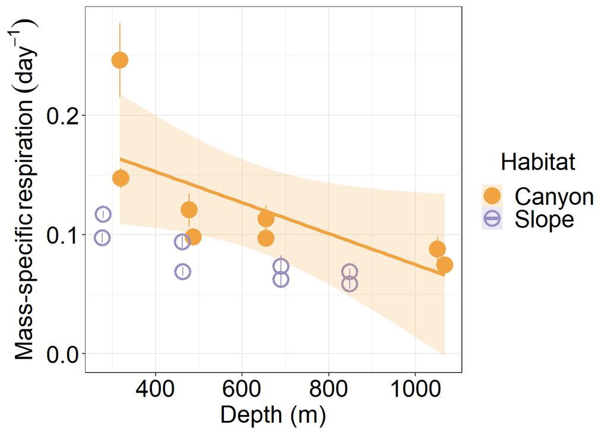

```r
(f5a <- ggplot(data=out,
       aes(x=Depth, y=daily.RtoM,
           ymin=daily.RtoM-daily.RtoM.se, ymax=daily.RtoM+daily.RtoM.se,
           shape=Habitat, colour=Habitat, fill=Habitat, linetype=Habitat))+
  geom_point(size=5, stroke=1.5)+
  stat_smooth(data=subset(out, Habitat=="Canyon"), method="lm", formula=y~x, alpha=0.2, size=1.5)+
  geom_errorbar(linetype=1)+
  scale_colour_manual(values=c("#f1a340", "#998ec3"))+
  scale_fill_manual(values=c("#f1a340", "#998ec3"))+
  scale_linetype_manual(values=c(1,2))+
  scale_shape_manual(values=c(19,1))+
  labs(x="Depth (m)", y=expression("Mass-specific"~respiration~(day^-1)))+
  theme_bw() %+replace% large #%+replace% dark
)
```

```r
save(f5a, file="../rds/f5a.rds")
```

## 2.2 Generalized Least Squares (GLS) modeling

#### 2.2.0.1 Main test

```r
f <- gls(daily.RtoM ~ Habitat+Depth+Cruise+Habitat:Depth+Habitat:Cruise+Depth:Cruise, data=out, method = "REML")
kable(summary(f)$tTable)
```

|  | Value | Std.Error | t-value | p-value |
| --- | --- | --- | --- | --- |
| (Intercept) | 0.1821037 | 0.0382096 | 4.7659106 | 0.0010212 |
| HabitatSlope | -0.0677988 | 0.0473343 | -1.4323388 | 0.1858495 |
| Depth | -0.0001102 | 0.0000549 | -2.0060388 | 0.0758110 |
| CruiseOR1_1126 | 0.0454496 | 0.0484605 | 0.9378696 | 0.3727960 |
| HabitatSlope:Depth | 0.0000552 | 0.0000692 | 0.7968575 | 0.4460451 |
| HabitatSlope:CruiseOR1_1126 | -0.0289441 | 0.0336173 | -0.8609901 | 0.4115936 |
| Depth:CruiseOR1_1126 | -0.0000394 | 0.0000673 | -0.5853244 | 0.5727111 |

```r
kable(anova(f))
```

|  | numDF | F-value | p-value |
| --- | --- | --- | --- |
| (Intercept) | 1 | 148.0909398 | 0.0000007 |
| Habitat | 1 | 6.6670295 | 0.0295965 |
| Depth | 1 | 10.4478845 | 0.0102844 |
| Cruise | 1 | 0.1914079 | 0.6720581 |
| Habitat:Depth | 1 | 0.6377833 | 0.4450767 |
| Habitat:Cruise | 1 | 0.6355728 | 0.4458405 |
| Depth:Cruise | 1 | 0.3426046 | 0.5727111 |

Significant habitat and depth effects.

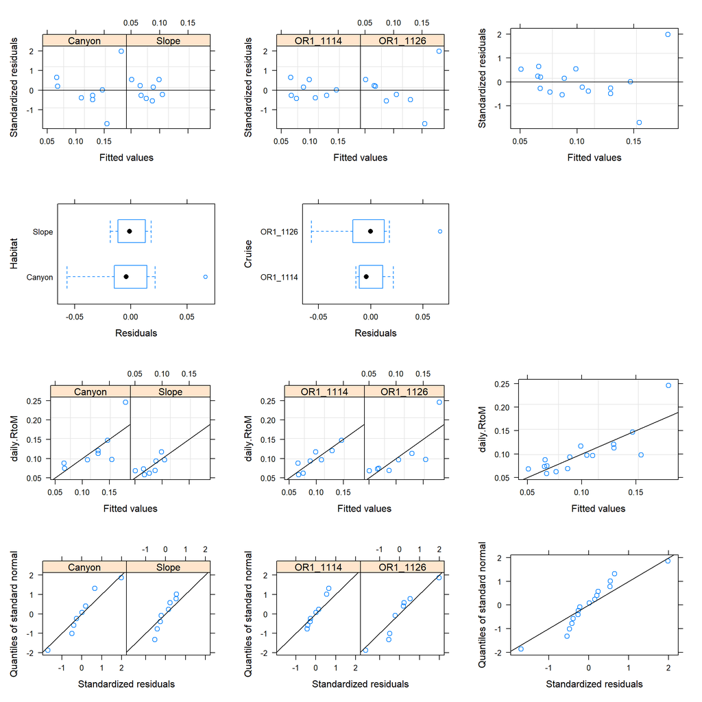

```r
# Function to plot dianotics plot
dianostic_plot <-
  function(f, y){
    # standardized residuals versus fitted values
    a1 <- plot(f, resid(., type = "p") ~ fitted(.) | Habitat, abline = 0)
    a2 <- plot(f, resid(., type = "p") ~ fitted(.) | Cruise, abline = 0)
    a3 <- plot(f, resid(., type = "p") ~ fitted(.), abline = 0)
    # box-plots of residuals
    b1<-plot(f, Habitat ~ resid(.))
    b2 <- plot(f, Cruise ~ resid(.))
    # observed versus fitted values
    c1<-plot(f, paste(paste(y, "fitted(.)", sep="~"), "Habitat", sep="|") %>% formula, abline = c(0,1))
    c2<-plot(f, paste(paste(y, "fitted(.)", sep="~"), "Cruise", sep="|") %>% formula, abline = c(0,1))
    c3<-plot(f, paste(y, "fitted(.)", sep="~") %>% formula, abline = c(0,1))
    # QQ plot
    d1<-qqnorm(f, ~ resid(., type = "p") | Habitat, abline = c(0,1))
    d2<-qqnorm(f, ~ resid(., type = "p") | Cruise, abline = c(0,1))
    d3<-qqnorm(f, ~ resid(., type = "p"), abline = c(0,1))

    print(a1, split=c(1,1,3,4), more=TRUE)
    print(a2, split=c(2,1,3,4), more=TRUE)
    print(a3, split=c(3,1,3,4), more=TRUE)
    print(b1, split=c(1,2,3,4), more=TRUE)
    print(b2, split=c(2,2,3,4), more=TRUE)
    #
    print(c1, split=c(1,3,3,4), more=TRUE)
    print(c2, split=c(2,3,3,4), more=TRUE)
    print(c3, split=c(3,3,3,4), more=TRUE)
    print(d1, split=c(1,4,3,4), more=TRUE)
    print(d2, split=c(2,4,3,4), more=TRUE)
    print(d3, split=c(3,4,3,4))
    }

dianostic_plot(f, y = "daily.RtoM")
```

# 3 Daily respiration in wet weight per square meter

## 3.1 Linear regression with depth

```r
splitBy(~Habitat, out) %>% lapply(FUN=function(x)lm(log10(respirationW)~Depth, data=x) %>% summary)
```

```
## $Canyon
##
## Call:
## lm(formula = log10(respirationW) ~ Depth, data = x)
##
## Residuals:
##      Min       1Q   Median       3Q      Max
## -0.46952 -0.24487 -0.04174  0.30651  0.49879
##
## Coefficients:
##               Estimate Std. Error t value Pr(>|t|)
## (Intercept)  0.5024753  0.3331733   1.508    0.182
## Depth       -0.0002043  0.0004853  -0.421    0.688
##
## Residual standard error: 0.3781 on 6 degrees of freedom
## Multiple R-squared:  0.02868,    Adjusted R-squared:  -0.1332
## F-statistic: 0.1772 on 1 and 6 DF,  p-value: 0.6885
##
##
## $Slope
##
## Call:
## lm(formula = log10(respirationW) ~ Depth, data = x)
##
## Residuals:
##      Min       1Q   Median       3Q      Max
## -0.22397 -0.16654  0.02759  0.14653  0.21828
##
## Coefficients:
##               Estimate Std. Error t value Pr(>|t|)
## (Intercept)  1.6775976  0.1916563   8.753 0.000123 ***
## Depth       -0.0010128  0.0003144  -3.221 0.018109 *
## ---
## Signif. codes:  0 '***' 0.001 '**' 0.01 '*' 0.05 '.' 0.1 ' ' 1
##
## Residual standard error: 0.193 on 6 degrees of freedom
## Multiple R-squared:  0.6336, Adjusted R-squared:  0.5726
## F-statistic: 10.38 on 1 and 6 DF,  p-value: 0.01811
```

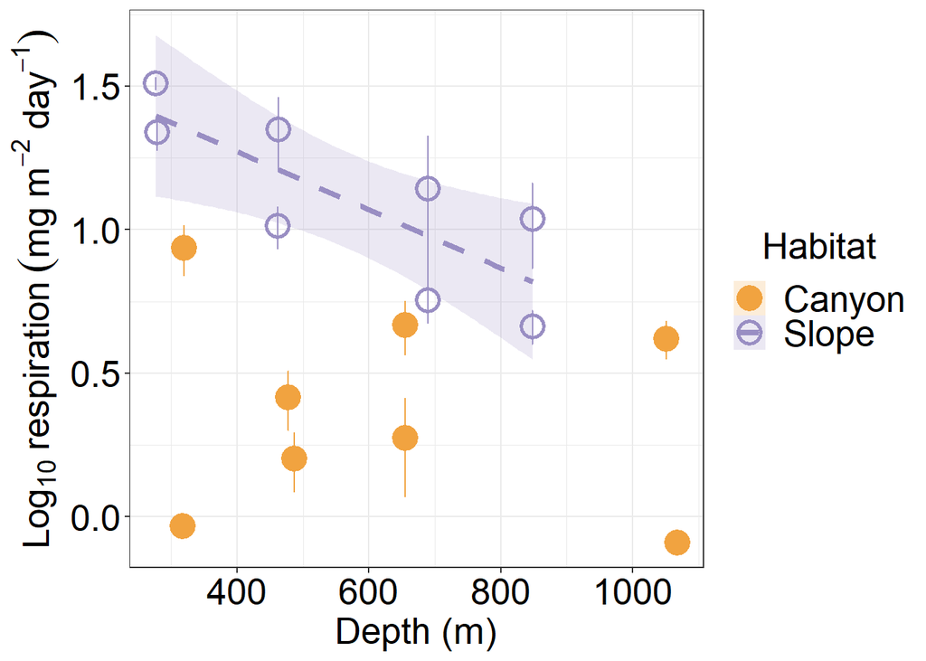

```r
(f5c <- ggplot(data=out,
       aes(x=Depth, y=log10(respirationW),
           ymin=log10(respirationW-respirationW.se), ymax=log10(respirationW+respirationW.se),
           shape=Habitat, colour=Habitat, fill=Habitat, linetype=Habitat))+
  geom_point(size=5, stroke=1.5)+
  stat_smooth(data=subset(out, Habitat=="Slope"), method="lm", formula=y~x, alpha=0.2, size=1.5)+
  geom_errorbar(linetype=1)+
  scale_colour_manual(values=c("#f1a340", "#998ec3"))+
  scale_fill_manual(values=c("#f1a340", "#998ec3"))+
  scale_linetype_manual(values=c(1,2))+
  scale_shape_manual(values=c(19,1))+
  labs(x="Depth (m)", y=expression(Log[10]~respiration~(mg~m^-2~day^-1)))+
  theme_bw() %+replace% large #%+replace% dark
)
```

```r
save(f5c, file="../rds/f5c.rds")
```

Respiration declined with depth on the slope.

## 3.2 Generalized Least Squares (GLS) modeling

Meiofauna respirations of each sample were averaged by station (i.e., average of three cores) before further statistical tests. We used Generalized Least Squares (GLS) modeling to examine the effects of habitat (canyon vs. slope), depth, and sampling time on the mean meiofauna respirations.

## 3.3 Main test

```r
f <- gls(log10(respirationW) ~ Habitat+Depth+Cruise+Habitat:Depth+Habitat:Cruise+Depth:Cruise, data=out, method = "REML")
kable(summary(f)$tTable)
```

|  | Value | Std.Error | t-value | p-value |
| --- | --- | --- | --- | --- |
| (Intercept) | 0.6372143 | 0.2333891 | 2.7302659 | 0.0232144 |
| HabitatSlope | 0.9443030 | 0.2891238 | 3.2660851 | 0.0097435 |
| Depth | 0.0000358 | 0.0003354 | 0.1067682 | 0.9173149 |
| CruiseOR1_1126 | -0.2883393 | 0.2960024 | -0.9741115 | 0.3554539 |
| HabitatSlope:Depth | -0.0008241 | 0.0004228 | -1.9492232 | 0.0830703 |
| HabitatSlope:CruiseOR1_1126 | 0.4798955 | 0.2053383 | 2.3370966 | 0.0442301 |
| Depth:CruiseOR1_1126 | -0.0004480 | 0.0004111 | -1.0897635 | 0.3041341 |

```r
kable(anova(f))
```

|  | numDF | F-value | p-value |
| --- | --- | --- | --- |
| (Intercept) | 1 | 209.270940 | 0.0000002 |
| Habitat | 1 | 50.813769 | 0.0000549 |
| Depth | 1 | 6.254464 | 0.0338123 |
| Cruise | 1 | 9.597989 | 0.0127623 |
| Habitat:Depth | 1 | 3.718548 | 0.0858989 |
| Habitat:Cruise | 1 | 6.169191 | 0.0347748 |
| Depth:Cruise | 1 | 1.187584 | 0.3041341 |

Significant habitat and depth effect, but there are also a significant interaction between habitat and cruise.

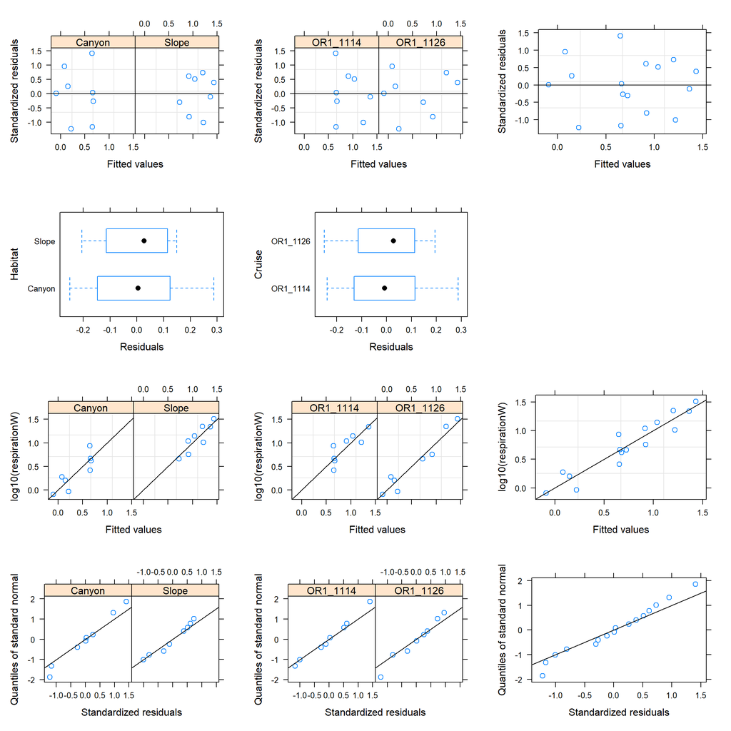

```r
# Dianotics plot
dianostic_plot(f, y = "log10(respirationW)")
```

## 3.4 Pairwise tests

```r
# In canyon
f <- gls(log10(respirationW) ~ Depth+Cruise+Depth:Cruise, data=subset(out, Habitat == "Canyon"), method = "REML")
kable(summary(f)$tTable)
```

|  | Value | Std.Error | t-value | p-value |
| --- | --- | --- | --- | --- |
| (Intercept) | 0.7972863 | 0.2852679 | 2.7948687 | 0.0490676 |
| Depth | -0.0002199 | 0.0004179 | -0.5263214 | 0.6264978 |
| CruiseOR1_1126 | -0.6033488 | 0.4014978 | -1.5027451 | 0.2073265 |
| Depth:CruiseOR1_1126 | 0.0000529 | 0.0005848 | 0.0905146 | 0.9322297 |

```r
kable(anova(f))
```

|  | numDF | F-value | p-value |
| --- | --- | --- | --- |
| (Intercept) | 1 | 21.5670280 | 0.0097047 |
| Depth | 1 | 0.4881988 | 0.5232240 |
| Cruise | 1 | 12.5238346 | 0.0240371 |
| Depth:Cruise | 1 | 0.0081929 | 0.9322297 |

```r
# On slope
f <- gls(log10(respirationW) ~ Depth+Cruise+Depth:Cruise, data=subset(out, Habitat == "Slope"), method = "REML")
kable(summary(f)$tTable)
```

|  | Value | Std.Error | t-value | p-value |
| --- | --- | --- | --- | --- |
| (Intercept) | 1.3512375 | 0.1822362 | 7.414757 | 0.0017654 |
| Depth | -0.0003841 | 0.0002989 | -1.284893 | 0.2681869 |
| CruiseOR1_1126 | 0.6508548 | 0.2573880 | 2.528691 | 0.0647548 |
| Depth:CruiseOR1_1126 | -0.0012543 | 0.0004222 | -2.970699 | 0.0411158 |

```r
kable(anova(f))
```

|  | numDF | F-value | p-value |
| --- | --- | --- | --- |
| (Intercept) | 1 | 576.813892 | 0.0000178 |
| Depth | 1 | 23.013376 | 0.0086657 |
| Cruise | 1 | 0.482056 | 0.5257082 |
| Depth:Cruise | 1 | 8.825053 | 0.0411158 |

```r
# OR1 1114
f <- gls(log10(respirationW) ~ Habitat+Depth+Habitat:Depth, data=subset(out, Cruise=="OR1_1114"), method = "REML")
kable(summary(f)$tTable)
```

|  | Value | Std.Error | t-value | p-value |
| --- | --- | --- | --- | --- |
| (Intercept) | 0.7972863 | 0.2514313 | 3.1709906 | 0.0338257 |
| HabitatSlope | 0.5539512 | 0.3780044 | 1.4654624 | 0.2166659 |
| Depth | -0.0002199 | 0.0003683 | -0.5971516 | 0.5825651 |
| HabitatSlope:Depth | -0.0001642 | 0.0005916 | -0.2774709 | 0.7951687 |

```r
kable(anova(f))
```

|  | numDF | F-value | p-value |
| --- | --- | --- | --- |
| (Intercept) | 1 | 159.3316153 | 0.0002268 |
| Habitat | 1 | 11.0892427 | 0.0291043 |
| Depth | 1 | 0.9677941 | 0.3809276 |
| Habitat:Depth | 1 | 0.0769901 | 0.7951687 |

```r
# OR1 1126
f <- gls(log10(respirationW) ~ Habitat+Depth+Habitat:Depth, data=subset(out, Cruise=="OR1_1126"), method = "REML")
kable(summary(f)$tTable)
```

|  | Value | Std.Error | t-value | p-value |
| --- | --- | --- | --- | --- |
| (Intercept) | 0.1939375 | 0.2089535 | 0.9281371 | 0.4058719 |
| HabitatSlope | 1.8081549 | 0.3153855 | 5.7331573 | 0.0045841 |
| Depth | -0.0001670 | 0.0003026 | -0.5518900 | 0.6104060 |
| HabitatSlope:Depth | -0.0014714 | 0.0004917 | -2.9925839 | 0.0402353 |

```r
kable(anova(f))
```

|  | numDF | F-value | p-value |
| --- | --- | --- | --- |
| (Intercept) | 1 | 94.395057 | 0.0006283 |
| Habitat | 1 | 67.757977 | 0.0011876 |
| Depth | 1 | 9.222888 | 0.0385183 |
| Habitat:Depth | 1 | 8.955559 | 0.0402353 |

Significant cruise effect in canyon and significant habitat effect during OR1 1114 & 1126

# 4 Daily respiration in carbon per square meter

## 4.1 Linear regression with depth

```r
splitBy(~Habitat, out) %>% lapply(FUN=function(x)lm(log10(respirationC)~Depth, data=x) %>% summary)
```

```
## $Canyon
##
## Call:
## lm(formula = log10(respirationC) ~ Depth, data = x)
##
## Residuals:
##     Min      1Q  Median      3Q     Max
## -0.4838 -0.3192 -0.1058  0.2145  0.7150
##
## Coefficients:
##               Estimate Std. Error t value Pr(>|t|)
## (Intercept) -0.5831027  0.4131684  -1.411    0.208
## Depth        0.0001049  0.0006018   0.174    0.867
##
## Residual standard error: 0.4689 on 6 degrees of freedom
## Multiple R-squared:  0.005035,   Adjusted R-squared:  -0.1608
## F-statistic: 0.03037 on 1 and 6 DF,  p-value: 0.8674
##
##
## $Slope
##
## Call:
## lm(formula = log10(respirationC) ~ Depth, data = x)
##
## Residuals:
##      Min       1Q   Median       3Q      Max
## -0.26996 -0.12548 -0.02801  0.08552  0.35874
##
## Coefficients:
##               Estimate Std. Error t value Pr(>|t|)
## (Intercept)  0.8830761  0.2305958   3.830  0.00866 **
## Depth       -0.0010730  0.0003783  -2.836  0.02971 *
## ---
## Signif. codes:  0 '***' 0.001 '**' 0.01 '*' 0.05 '.' 0.1 ' ' 1
##
## Residual standard error: 0.2323 on 6 degrees of freedom
## Multiple R-squared:  0.5728, Adjusted R-squared:  0.5016
## F-statistic: 8.045 on 1 and 6 DF,  p-value: 0.02971
```

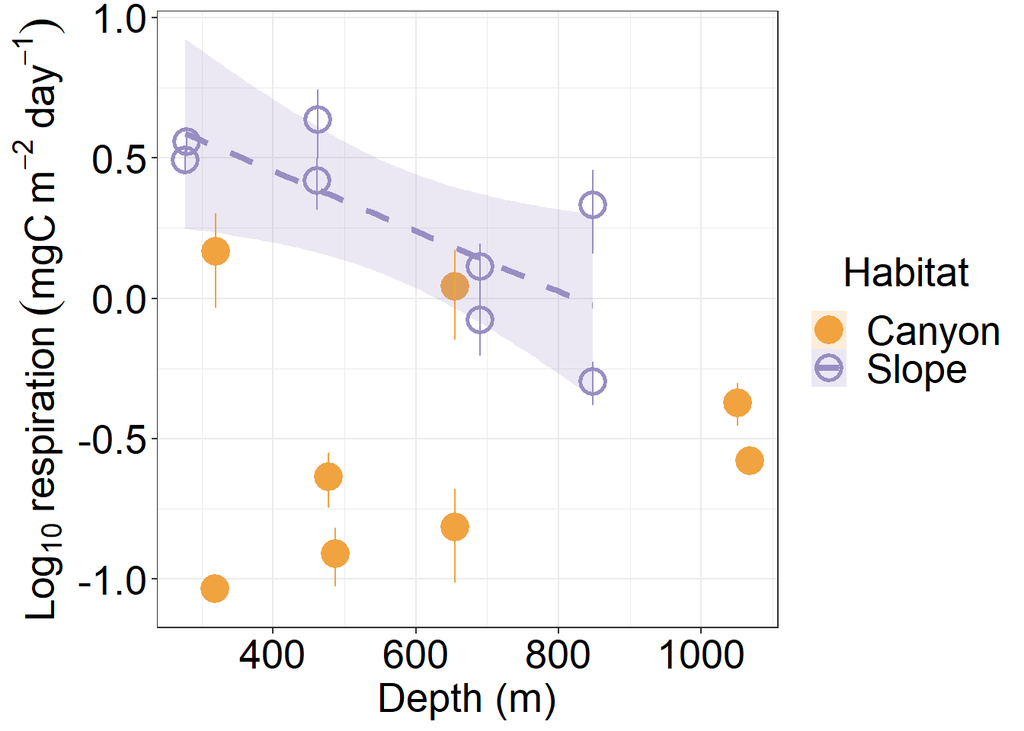

```r
ggplot(data=out,
       aes(x=Depth, y=log10(respirationC),
           ymin=log10(respirationC-respirationC.se), ymax=log10(respirationC+respirationC.se),
           shape=Habitat, colour=Habitat, fill=Habitat, linetype=Habitat))+
  geom_point(size=5, stroke=1.5)+
  stat_smooth(data=subset(out, Habitat=="Slope"), method="lm", formula=y~x, alpha=0.2, size=1.5)+
  geom_errorbar(linetype=1)+
  scale_colour_manual(values=c("#f1a340", "#998ec3"))+
  scale_fill_manual(values=c("#f1a340", "#998ec3"))+
  scale_linetype_manual(values=c(1,2))+
  scale_shape_manual(values=c(19,1))+
  labs(x="Depth (m)", y=expression(Log[10]~respiration~(mgC~m^-2~day^-1)))+
  theme_bw() %+replace% large #%+replace% dark
```

Respiration declined with depth on the slope.

# 5 Daily respiration in J per square meter

## 5.1 Linear regression with depth

```r
splitBy(~Habitat, out) %>% lapply(FUN=function(x)lm(log10(respirationJ)~Depth, data=x) %>% summary)
```

```
## $Canyon
##
## Call:
## lm(formula = log10(respirationJ) ~ Depth, data = x)
##
## Residuals:
##     Min      1Q  Median      3Q     Max
## -0.4741 -0.2871 -0.1144  0.2303  0.6797
##
## Coefficients:
##              Estimate Std. Error t value Pr(>|t|)
## (Intercept) 1.086e+00  3.939e-01   2.757    0.033 *
## Depth       6.681e-05  5.737e-04   0.116    0.911
## ---
## Signif. codes:  0 '***' 0.001 '**' 0.01 '*' 0.05 '.' 0.1 ' ' 1
##
## Residual standard error: 0.447 on 6 degrees of freedom
## Multiple R-squared:  0.002255,   Adjusted R-squared:  -0.164
## F-statistic: 0.01356 on 1 and 6 DF,  p-value: 0.9111
##
##
## $Slope
##
## Call:
## lm(formula = log10(respirationJ) ~ Depth, data = x)
##
## Residuals:
##      Min       1Q   Median       3Q      Max
## -0.24044 -0.09813 -0.03767  0.06540  0.34276
##
## Coefficients:
##               Estimate Std. Error t value Pr(>|t|)
## (Intercept)  2.5050682  0.2154288  11.628 2.44e-05 ***
## Depth       -0.0010794  0.0003534  -3.054   0.0224 *
## ---
## Signif. codes:  0 '***' 0.001 '**' 0.01 '*' 0.05 '.' 0.1 ' ' 1
##
## Residual standard error: 0.217 on 6 degrees of freedom
## Multiple R-squared:  0.6086, Adjusted R-squared:  0.5434
## F-statistic: 9.329 on 1 and 6 DF,  p-value: 0.02239
```

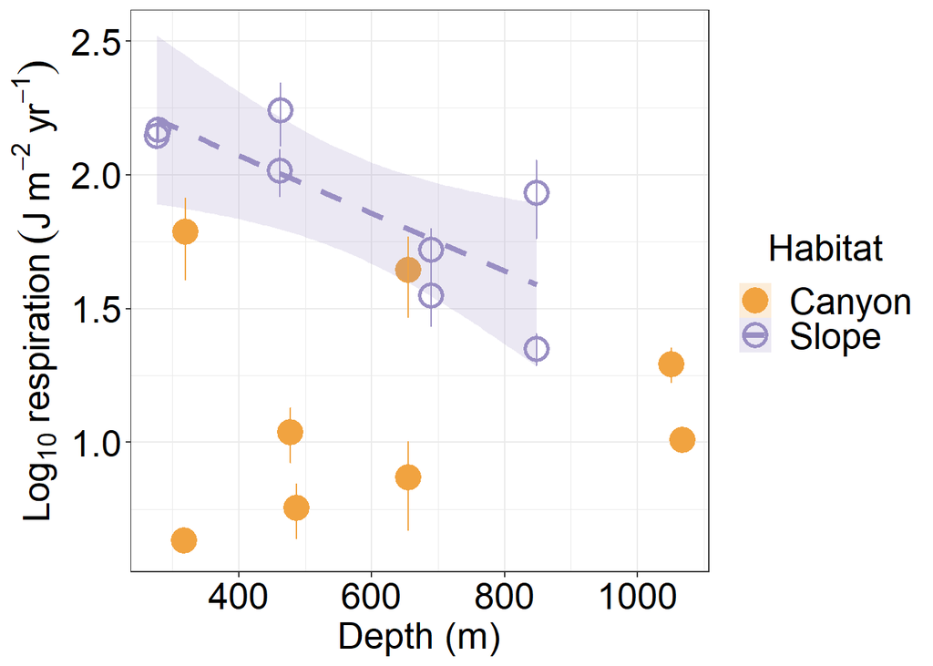

```r
ggplot(data=out,
       aes(x=Depth, y=log10(respirationJ),
           ymin=log10(respirationJ-respirationJ.se), ymax=log10(respirationJ+respirationJ.se),
           shape=Habitat, colour=Habitat, fill=Habitat, linetype=Habitat))+
  geom_point(size=5, stroke=1.5)+
  stat_smooth(data=subset(out, Habitat=="Slope"), method="lm", formula=y~x, alpha=0.2, size=1.5)+
  geom_errorbar(linetype=1)+
  scale_colour_manual(values=c("#f1a340", "#998ec3"))+
  scale_fill_manual(values=c("#f1a340", "#998ec3"))+
  scale_linetype_manual(values=c(1,2))+
  scale_shape_manual(values=c(19,1))+
  labs(x="Depth (m)", y=expression(Log[10]~respiration~(J~m^-2~yr^-1)))+
  theme_bw() %+replace% large #%+replace% dark
```

Respiration declined with depth on the slope.